# Análisis de la calidad del vino - UCI

## Carga y análisis exploratorio de los datos (EDA)

Vamos a realizar el análisis y predicción mediante un modelo de regresión múltiple, probando a hacerlo primero sin estandarizar las variables, y luego aplicando la estandarización.

Primero, importamos los módulos necesarios:

```python
import pandas as pd
import numpy as np
import seaborn as sns
import matplotlib.pyplot as plt
from sklearn.linear_model import LinearRegression
from sklearn.model_selection import train_test_split
from sklearn.metrics import mean_squared_error, root_mean_squared_error, r2_score
import statsmodels.api as sm
```

Descargamos el archivo en memoria y lo leemos directamente, creando un DataFrame, ya que es una funcionalidad de Pandas:

```python
url = 'https://archive.ics.uci.edu/ml/machine-learning-databases/wine-quality/winequality-red.csv'
df = pd.read_csv(url, sep=';')
df
```

|  | fixed acidity | volatile acidity | citric acid | residual sugar | chlorides | free sulfur dioxide | total sulfur dioxide | density | pH | sulphates | alcohol | quality |
| --- | --- | --- | --- | --- | --- | --- | --- | --- | --- | --- | --- | --- |
| 0 | 7.4 | 0.700 | 0.00 | 1.9 | 0.076 | 11.0 | 34.0 | 0.99780 | 3.51 | 0.56 | 9.4 | 5 |
| 1 | 7.8 | 0.880 | 0.00 | 2.6 | 0.098 | 25.0 | 67.0 | 0.99680 | 3.20 | 0.68 | 9.8 | 5 |
| 2 | 7.8 | 0.760 | 0.04 | 2.3 | 0.092 | 15.0 | 54.0 | 0.99700 | 3.26 | 0.65 | 9.8 | 5 |
| 3 | 11.2 | 0.280 | 0.56 | 1.9 | 0.075 | 17.0 | 60.0 | 0.99800 | 3.16 | 0.58 | 9.8 | 6 |
| 4 | 7.4 | 0.700 | 0.00 | 1.9 | 0.076 | 11.0 | 34.0 | 0.99780 | 3.51 | 0.56 | 9.4 | 5 |
| ... | ... | ... | ... | ... | ... | ... | ... | ... | ... | ... | ... | ... |
| 1594 | 6.2 | 0.600 | 0.08 | 2.0 | 0.090 | 32.0 | 44.0 | 0.99490 | 3.45 | 0.58 | 10.5 | 5 |
| 1595 | 5.9 | 0.550 | 0.10 | 2.2 | 0.062 | 39.0 | 51.0 | 0.99512 | 3.52 | 0.76 | 11.2 | 6 |
| 1596 | 6.3 | 0.510 | 0.13 | 2.3 | 0.076 | 29.0 | 40.0 | 0.99574 | 3.42 | 0.75 | 11.0 | 6 |
| 1597 | 5.9 | 0.645 | 0.12 | 2.0 | 0.075 | 32.0 | 44.0 | 0.99547 | 3.57 | 0.71 | 10.2 | 5 |
| 1598 | 6.0 | 0.310 | 0.47 | 3.6 | 0.067 | 18.0 | 42.0 | 0.99549 | 3.39 | 0.66 | 11.0 | 6 |

1599 rows × 12 columns

Podemos ver que los datos consisten en 1599 entradas con 12 características cada una.  
La última característica es la calidad del vino, y será el objetivo a predecir.

Ahora, analicemos algunas características estadísticas de los datos:

```python
for col in df.columns:
    print(f'\n- Columna "{col}":')
    print(df[col].describe())
```

```
- Columna "fixed acidity":
count    1599.000000
mean        8.319637
std         1.741096
min         4.600000
25%         7.100000
50%         7.900000
75%         9.200000
max        15.900000
Name: fixed acidity, dtype: float64

- Columna "volatile acidity":
count    1599.000000
mean        0.527821
std         0.179060
min         0.120000
25%         0.390000
50%         0.520000
75%         0.640000
max         1.580000
Name: volatile acidity, dtype: float64

- Columna "citric acid":
count    1599.000000
mean        0.270976
std         0.194801
min         0.000000
25%         0.090000
50%         0.260000
75%         0.420000
max         1.000000
Name: citric acid, dtype: float64

- Columna "residual sugar":
count    1599.000000
mean        2.538806
std         1.409928
min         0.900000
25%         1.900000
50%         2.200000
```

[output cut: 76 more lines]

```
50%        10.200000
75%        11.100000
max        14.900000
Name: alcohol, dtype: float64

- Columna "quality":
count    1599.000000
mean        5.636023
std         0.807569
min         3.000000
25%         5.000000
50%         6.000000
75%         6.000000
max         8.000000
Name: quality, dtype: float64
```

Como se puede observar, las diferentes columnas tienen rangos bastante dispares, lo cual puede ser indicativo de la necesidad de estandarización de los datos.

Veamos ahora si las características tienen datos faltantes o vacíos:

```python
df.info(memory_usage=False, verbose=True)
```

```
<class 'pandas.core.frame.DataFrame'>
RangeIndex: 1599 entries, 0 to 1598
Data columns (total 12 columns):
 #   Column                Non-Null Count  Dtype
---  ------                --------------  -----
 0   fixed acidity         1599 non-null   float64
 1   volatile acidity      1599 non-null   float64
 2   citric acid           1599 non-null   float64
 3   residual sugar        1599 non-null   float64
 4   chlorides             1599 non-null   float64
 5   free sulfur dioxide   1599 non-null   float64
 6   total sulfur dioxide  1599 non-null   float64
 7   density               1599 non-null   float64
 8   pH                    1599 non-null   float64
 9   sulphates             1599 non-null   float64
 10  alcohol               1599 non-null   float64
 11  quality               1599 non-null   int64
dtypes: float64(11), int64(1)
```

De estos datos podemos extraer 2 conclusiones:

- No hay datos vacíos
- Todas las características son númericas, y ninguna categórica

### Observaciones:

- Los datos contienen 12 características y 1599 entradas.
- Los datos son de tipo numérico continuo.
- No hay datos faltantes o vacíos.

## Modelo con características no estandarizadas

En primer lugar, realizaré un modelo de regresión lineal sobre las características tal cual nos llegan, para comprobar si, al estandarizar, se mejora el rendimiento del modelo.

### Preprocesamiento

Vamos a crear los conjuntos de entrenamiento y prueba.

```python
X = df.drop('quality', axis=1)
y = df['quality']
X_train, X_test, y_train, y_test = train_test_split(X, y, test_size=0.2, random_state=17)
```

### Creación del modelo

En este ejercicio, usaremos un modelo de regresión lineal.

```python
modelo = LinearRegression()
modelo.fit(X_train, y_train)
```

```
LinearRegression()
```

A continuación, hacemos una predicción con el modelo:

```python
y_pred = modelo.predict(X_test)
```

### Visualización

Graficamos los resultados para comparar la predicción con los datos reales:

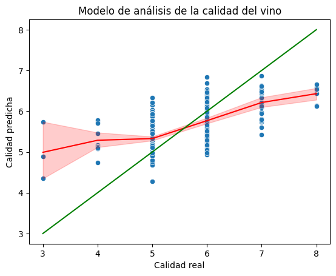

```python
sns.scatterplot(x=y_test, y=y_pred)
sns.lineplot(x=y_test, y=y_pred, color='red')
plt.plot([min(y_test), max(y_test)], [min(y_test), max(y_test)], color='green')
plt.xlabel('Calidad real')
plt.ylabel('Calidad predicha')
plt.title('Modelo de análisis de la calidad del vino')
plt.show()
```

Podemos ver claramente la discrepancia entre la línea roja (nuestro modelo) y la línea verde (un modelo ideal).

### Evaluación del modelo

Vamos a evaluar el modelo usando el coeficiente de determinación y el error cuadrático medio.

```python
mse_nosc = mean_squared_error(y_test, y_pred)
r2_nosc = r2_score(y_test, y_pred)
rmse_nosc = root_mean_squared_error(y_test, y_pred)
print("R²:", round(r2_nosc, 4))
print("MSE:", round(mse_nosc, 4))
```

```
R²: 0.4133
MSE: 0.4
```

La capacidad predictiva del modelo es aceptable a baja. Según las métricas, sólo el 41% de la variabilidad en la calidad puede ser explicada por las variables independientes (R²), pero da unos resultados buenos en cuanto a error (MSE).

Ahora vamos a ver la distribución de los residuos.

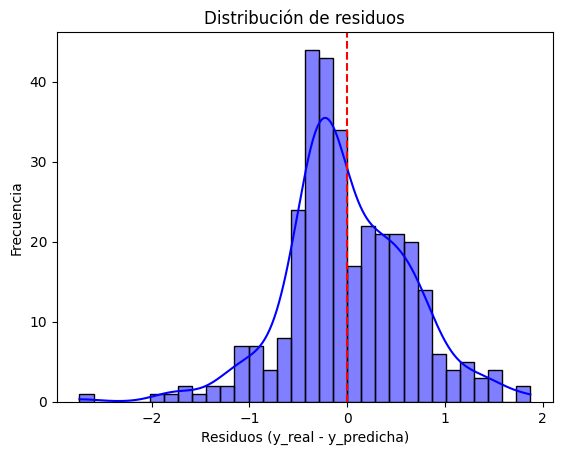

```python
residuos_nosc = y_test - y_pred
sns.histplot(residuos_nosc, bins=32, kde=True, color="blue")
plt.axvline(x=0, color='red', linestyle='--')
plt.title("Distribución de residuos")
plt.xlabel("Residuos (y_real - y_predicha)")
plt.ylabel("Frecuencia")
plt.show()
```

Los residuos son los errores, y ver su distribución puede ayudar a encontrar anomalías o inferir si se requiere un modelo más complejo para la tarea.

En este caso, observamos una distribución bastante parecida a la normal con los valores centrados en 0, aunque ligeramente inclinada. Indica que el modelo es funcional.

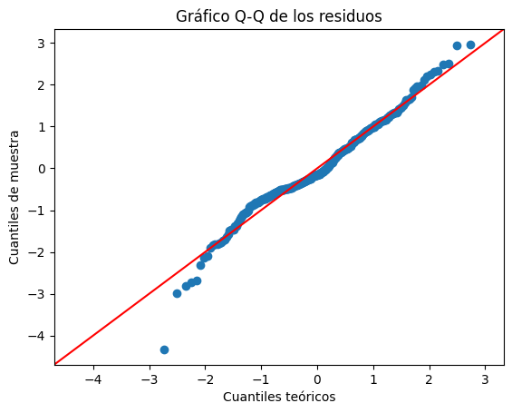

```python
sm.qqplot(residuos_nosc, line='45', fit=True)
plt.title('Gráfico Q-Q de los residuos')
plt.xlabel('Cuantiles teóricos')
plt.ylabel('Cuantiles de muestra')
plt.show()
```

En esta gráfica podemos ver la distribución de los residuos (puntos azules) en comparación con lo esperable de una distribución normal (línea roja). Exceptuando unos pocos puntos en la cola izquierda, y uno en especial, el modelo tiene los errores en una distribución aproximadamente normal (también llamada gaussiana o campana de Gauss)

### Observaciones

Incluso sin escalar los datos, parece que el rendimiento del modelo no es malo. Es posible que mejore con escalado y selección de características.

## Modelo con características estandarizadas

Ahora probaremos a estandarizar las variables antes de entrenar el modelo.

### Preprocesamiento

En este paso, usaré StandardScaler de Scikit-learn para estandarizar los datos, y crearé los conjuntos de entrenamiento y prueba.

```python
from sklearn.preprocessing import StandardScaler

scaler_X, scaler_y = StandardScaler(), StandardScaler()
X_sc = scaler_X.fit_transform(X)
y_sc = scaler_y.fit_transform(pd.DataFrame(y))

X_sc_train, X_sc_test, y_sc_train, y_sc_test = train_test_split(X_sc, y_sc, test_size=0.2, random_state=17)
```

### Creación del modelo

La creación del modelo es igual a la que escribimos en la sección anterior, sólo que con los datos ya estandarizados:

```python
modelo_sc = LinearRegression()
modelo_sc.fit(X_sc_train, y_sc_train)
```

```
LinearRegression()
```

Dado que la predicción la recibiremos en valores escalados, para comprobarlo sobre datos reales es necesario hacer la conversión inversa.

```python
y_pred_sc = modelo_sc.predict(X_sc_test)
y_pred_nosc = scaler_y.inverse_transform(y_pred_sc)
y_pred_nosc = y_pred_nosc.reshape(len(y_pred_nosc))
```

### Visualización

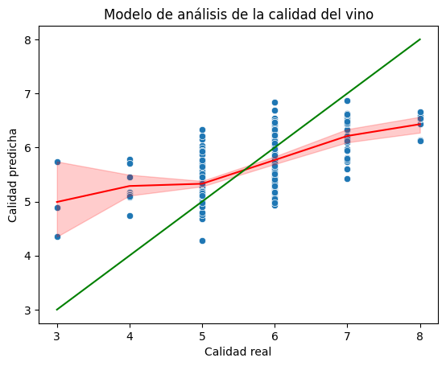

```python
sns.scatterplot(x=y_test, y=y_pred_nosc)
sns.lineplot(x=y_test, y=y_pred_nosc, color='red')
plt.plot([min(y_test), max(y_test)], [min(y_test), max(y_test)], color='green')
plt.xlabel('Calidad real')
plt.ylabel('Calidad predicha')
plt.title('Modelo de análisis de la calidad del vino')
plt.show()
```

Como podemos ver, la gráfica es prácticamente igual que en los datos sin escalar.

### Evaluación del modelo

```python
mse_sc = mean_squared_error(y_test, y_pred_nosc)
r2_sc = r2_score(y_test, y_pred_nosc)
print("R²:", round(r2_sc, 4))
print("MSE: ", round(mse_sc, 4))
```

```
R²: 0.4133
MSE:  0.4
```

Las puntuaciones en R² y MSE son exactamente iguales que entrenando el modelo sobre los datos sin escalar, por tanto el modelo no mejora con el escalado.

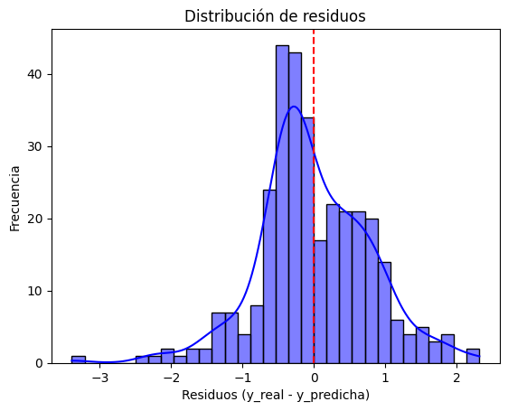

```python
residuos = y_sc_test.reshape(len(y_sc_test)) - y_pred_sc.reshape(len(y_pred_sc))
sns.histplot(residuos, bins=32, kde=True, color="blue")
plt.axvline(x=0, color='red', linestyle='--')
plt.title("Distribución de residuos")
plt.xlabel("Residuos (y_real - y_predicha)")
plt.ylabel("Frecuencia")
plt.show()
```

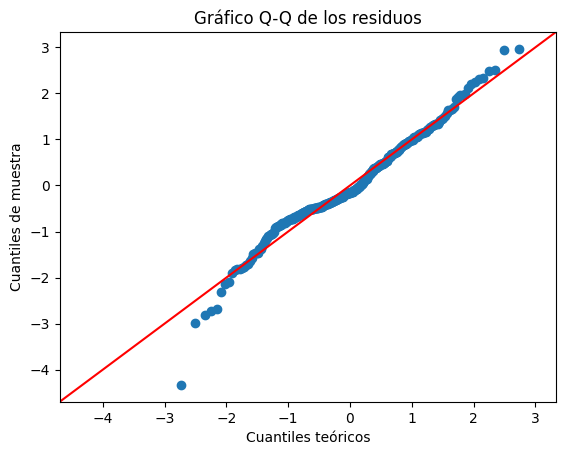

```python
sm.qqplot(residuos, line='45', fit=True)
plt.title('Gráfico Q-Q de los residuos')
plt.xlabel('Cuantiles teóricos')
plt.ylabel('Cuantiles de muestra')
plt.show()
```

Ambos gráficos son iguales a los del modelo entrenado sin escalar.

### Observaciones

Parece que aplicar el escalado de las características dependientes no ha resultado en una mejoría de la capacidad predictiva del modelo.

## Selección de características

En esta sección, vamos a analizar las características para ver si hay un exceso de colinealidad que esté distorsionando el modelo.

### Matriz de correlación

Utilizando el método ".corr()" de pandas, podemos crear un nuevo DataFrame que contiene la correlación entre las distintas características de manera muy sencilla.

Veamos cómo se ve la matriz de correlación en un mapa de calor.

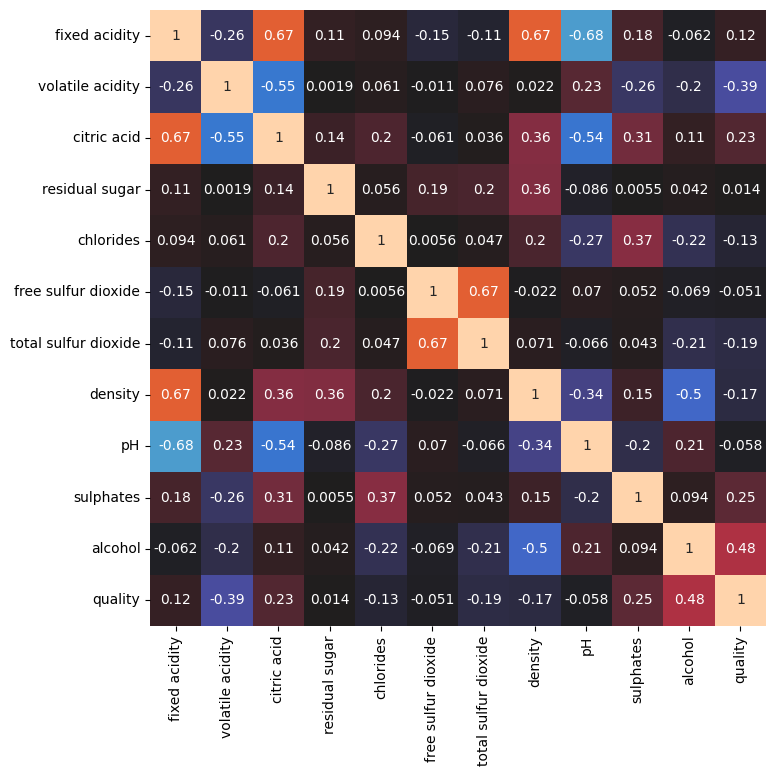

```python
corr_matriz = df.corr()
plt.figure(figsize=(8,8))
sns.heatmap(corr_matriz, vmin=-1, vmax=1, annot=True, cmap='icefire', square=True, cbar=False)
plt.show()
```

Ahora eliminemos aquellas correlaciones que sean inferiores al 60%, para poder evaluar mejor la colinealidad.

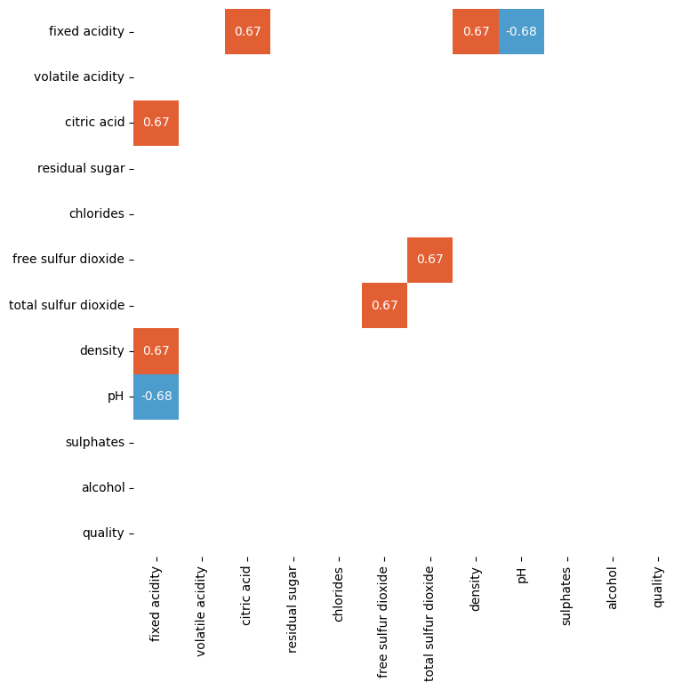

```python
corr_matriz_alta = corr_matriz[(abs(corr_matriz) >= 0.6) & (corr_matriz != 1)]
plt.figure(figsize=(8,8))
sns.heatmap(corr_matriz_alta, vmin=-1, vmax=1, annot=True, cmap='icefire', square=True, cbar=False)
plt.show()
```

Podemos observar una correlación de 2/3 aproximadamente entre acidez fijada y la densidad y el ácido cítrico, y entre el SO2 total y el SO2 libre.  
Y vemos una correlación negativa del 68% entre el pH y la acidez fijada, debido a que una mayor acidez comporta un menor pH.

### Factor de Inflación de la Varianza (VIF)

Ahora vamos a explorar otro factor llamado Factor de Inflación de la Varianza o VIF, que nos indica cuánto aumenta la varianza al incluir una nueva característica de entrenamiento al modelo.

#### Tabla comparativa de VIF

```python
from statsmodels.stats.outliers_influence import variance_inflation_factor

vif_data = pd.DataFrame()
vif_data["Característica"] = df.columns
vif_data["VIF"] = [round(variance_inflation_factor(df.values, i), 4) for i in range(df.shape[1])]
print("\nFactor de Inflación de la Varianza (VIF) para cada característica:\n", vif_data.sort_values(by='VIF', ascending=False))
```

```
Factor de Inflación de la Varianza (VIF) para cada característica:
           Característica        VIF
7                density  1528.1543
8                     pH  1078.1711
10               alcohol   147.6163
11               quality    77.7283
0          fixed acidity    74.4553
9              sulphates    22.4621
1       volatile acidity    17.9609
2            citric acid     9.1925
4              chlorides     6.6413
6   total sulfur dioxide     6.6053
5    free sulfur dioxide     6.4606
3         residual sugar     4.6640
```

Como podemos ver, algunas características tienen una colinealidad extrema, llegando a más de 1000 cuando un valor superior a 5 ó 10 se considera alto.

Veamos si eliminando las características con mayor colinealidad, mejora la precisión del modelo.

```python
X_1 = df.drop(['quality', 'pH', 'density', 'fixed acidity'], axis=1)
vif_data = pd.DataFrame()
vif_data["Característica"] = X_1.columns
vif_data["VIF"] = [round(variance_inflation_factor(X_1.values, i), 4) for i in range(X_1.shape[1])]
print("\nFactor de Inflación de la Varianza (VIF) para cada característica:\n", vif_data.sort_values(by='VIF', ascending=False))
```

```
Factor de Inflación de la Varianza (VIF) para cada característica:
          Característica      VIF
7               alcohol  31.9152
6             sulphates  20.6487
0      volatile acidity  12.8800
4   free sulfur dioxide   6.3497
3             chlorides   5.9034
5  total sulfur dioxide   5.9008
1           citric acid   4.9139
2        residual sugar   4.6378
```

#### Modelo y visualización

Vamos a escalar los datos con sus características ya seleccionadas, crear los conjuntos de entrenamiento y prueba, crear un modelo, entrenarlo y mostrar sus predicciones.

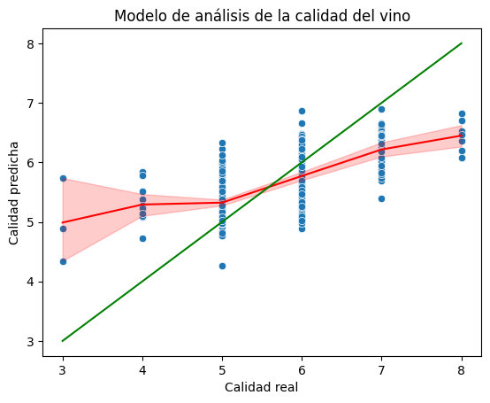

```python
scaler_X_1 = StandardScaler()
X_sc_1 = scaler_X.fit_transform(X_1)

X_1_sc_train, X_1_sc_test, y_sc_train, y_sc_test = train_test_split(X_sc_1, y_sc, test_size=0.2, random_state=17)
modelo_sc_1 = LinearRegression()
modelo_sc_1.fit(X_1_sc_train, y_sc_train)

y_pred_sc_1 = modelo_sc_1.predict(X_1_sc_test)

y_pred_nosc_1 = scaler_y.inverse_transform(y_pred_sc_1)
y_pred_nosc_1 = y_pred_nosc_1.reshape(len(y_pred_nosc_1))

sns.scatterplot(x=y_test, y=y_pred_nosc_1)
sns.lineplot(x=y_test, y=y_pred_nosc_1, color='red')
plt.plot([min(y_test), max(y_test)], [min(y_test), max(y_test)], color='green')
plt.xlabel('Calidad real')
plt.ylabel('Calidad predicha')
plt.title('Modelo de análisis de la calidad del vino')
plt.show()
```

Podemos observar que la precisión del modelo sigue siendo baja, a juzgar por la gráfica.

#### Evaluación del modelo

```python
mse_sc_1 = mean_squared_error(y_test, y_pred_nosc_1)
r2_sc_1 = r2_score(y_test, y_pred_nosc_1)

print("R²:", round(r2_sc_1, 4))
print("MSE: ", round(mse_sc_1, 4))
```

```
R²: 0.4207
MSE:  0.395
```

Podemos ver que la puntuación de rendimiento del modelo ha mejorado ligeramente.

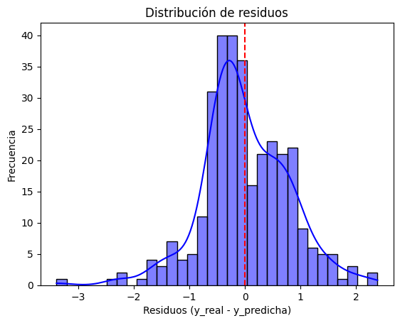

```python
residuos = y_sc_test.reshape(len(y_sc_test)) - y_pred_sc_1.reshape(len(y_pred_sc_1))
sns.histplot(residuos, bins=32, kde=True, color="blue")
plt.axvline(x=0, color='red', linestyle='--')
plt.title("Distribución de residuos")
plt.xlabel("Residuos (y_real - y_predicha)")
plt.ylabel("Frecuencia")
plt.show()
```

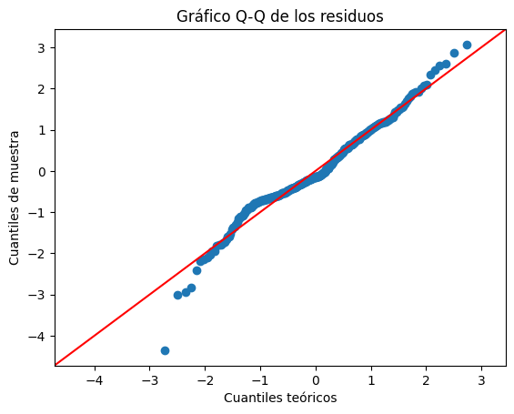

```python
sm.qqplot(residuos, line='45', fit=True)
plt.title('Gráfico Q-Q de los residuos')
plt.xlabel('Cuantiles teóricos')
plt.ylabel('Cuantiles de muestra')
plt.show()
```

Los residuos siguen una distribución aproximadamente normal, con algunas diferencias menores respecto a los modelos anteriores.

#### Observaciones

La selección de características mediante VIF ha producido, en este caso, un incremento marginal de la capacidad predictiva del modelo.  
Cabe resaltar el caso especial de la característica "alcohol", ya que muestra alta colinealidad pero también parece explicar buena parte de la variabilidad de la calidad del vino.

## PCA

### Análisis

```python
from sklearn.decomposition import PCA

pca = PCA(random_state=17)
X_pca = pca.fit_transform(X_sc)

varianza_explicada = pca.explained_variance_ratio_
varianza_acumulada = np.cumsum(varianza_explicada)
for num, var in enumerate(varianza_explicada):
    col = df.columns[num]
    print(f'- {col}')
    print(f"\tVarianza: {round(varianza_explicada[num]* 100, 2) }%")
    print(f"\tVarianza acumulada: {round(varianza_acumulada[num]* 100, 2) }%")
```

```
- fixed acidity
	Varianza: 28.17%
	Varianza acumulada: 28.17%
- volatile acidity
	Varianza: 17.51%
	Varianza acumulada: 45.68%
- citric acid
	Varianza: 14.1%
	Varianza acumulada: 59.78%
- residual sugar
	Varianza: 11.03%
	Varianza acumulada: 70.81%
- chlorides
	Varianza: 8.72%
	Varianza acumulada: 79.53%
- free sulfur dioxide
	Varianza: 6.0%
	Varianza acumulada: 85.52%
- total sulfur dioxide
	Varianza: 5.31%
	Varianza acumulada: 90.83%
- density
	Varianza: 3.85%
	Varianza acumulada: 94.68%
- pH
	Varianza: 3.13%
	Varianza acumulada: 97.81%
- sulphates
	Varianza: 1.65%
	Varianza acumulada: 99.46%
- alcohol
	Varianza: 0.54%
	Varianza acumulada: 100.0%
```

Aquí se muestra la varianza explicada por cada uno de los componentes principales a utilizar en orden descendente, y el acumulado.

```python
n_components = np.argmax(varianza_acumulada >= 0.95) + 1
X_pca_reduced = X_pca[:, :n_components]
X_pca_train, X_pca_test, y_pca_train, y_pca_test = train_test_split(X_pca_reduced, y_sc, test_size=0.2, random_state=17)

print(f"Usando los primeros {n_components} componentes principales.")
```

```
Usando los primeros 9 componentes principales.
```

### Creación de modelo

Ahora, seleccionamos los componentes que aportan a la varianza hasta el 95%, y el resto los descartamos.  
En la siguiente celda, crearemos el modelo basado en esas características.

```python
modelo_pca = LinearRegression()
modelo_pca.fit(X_pca_train, y_pca_train)
y_pred_pca = modelo_pca.predict(X_pca_test)
y_pca_nosc = scaler_y.inverse_transform(y_pred_pca)
y_pca_nosc = y_pca_nosc.reshape(len(y_pca_nosc))
```

### Visualización

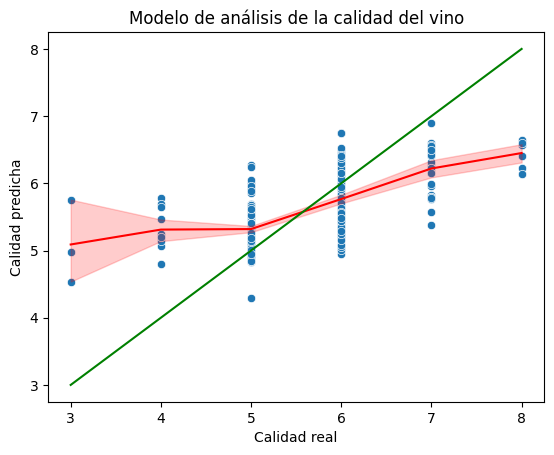

```python
sns.scatterplot(x=y_test, y=y_pca_nosc)
sns.lineplot(x=y_test, y=y_pca_nosc, color='red')
plt.plot([min(y_test), max(y_test)], [min(y_test), max(y_test)], color='green')
plt.xlabel('Calidad real')
plt.ylabel('Calidad predicha')
plt.title('Modelo de análisis de la calidad del vino')
plt.show()
```

No se observa una mejora significativa del modelo.

### Evaluación del modelo

La capacidad predictiva de este modelo después de la PCA es ligeramente mayor que los anteriores:

```python
mse_pca = mean_squared_error(y_test, y_pca_nosc)
r2_pca = r2_score(y_test, y_pca_nosc)

print("R²:", round(r2_pca, 4))
print("MSE: ", round(mse_pca, 4))
```

```
R²: 0.423
MSE:  0.3934
```

No se observan diferencias significativas en los residuos: todavía siguen una distribución aproximadamente normal.

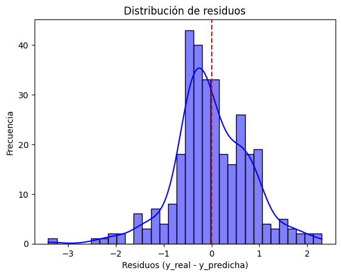

```python
residuos = y_pca_test.reshape(len(y_pca_test)) - y_pred_pca.reshape(len(y_pred_pca))
sns.histplot(residuos, bins=32, kde=True, color="blue")
plt.axvline(x=0, color='red', linestyle='--')
plt.title("Distribución de residuos")
plt.xlabel("Residuos (y_real - y_predicha)")
plt.ylabel("Frecuencia")
plt.show()
```

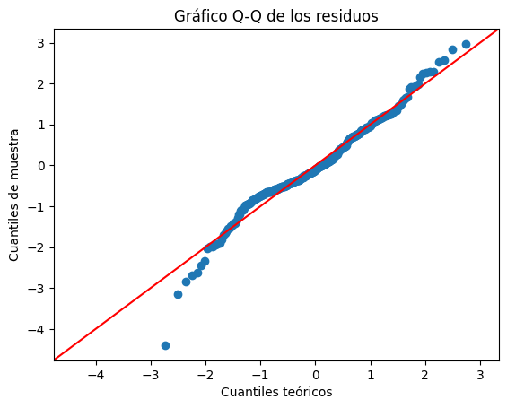

```python
sm.qqplot(residuos, line='45', fit=True)
plt.title('Gráfico Q-Q de los residuos')
plt.xlabel('Cuantiles teóricos')
plt.ylabel('Cuantiles de muestra')
plt.show()
```

### Observaciones

Hemos conseguido una ligera mejoría de la capacidad predictiva del modelo, pero no muy alta. Cabe preguntarse si no habrá otroas factores que ignoramos o se necesite un modelo distinto.

## Regresión polinómica

El siguiente paso es hacer una regresión polinómica para ver si podemos mejorar el modelo.  
Vamos a probar a crear modelos de grado 1 a 4, y elegiremos que mejor resultado nos de.

```python
from sklearn.preprocessing import PolynomialFeatures

for i in range(1,5):
    poly = PolynomialFeatures(degree=i)
    X_poly_train = poly.fit_transform(X_1_sc_train)
    X_poly_test = poly.fit_transform(X_1_sc_test)

    modelo_poly = LinearRegression()
    modelo_poly.fit(X_poly_train, y_sc_train)

    y_pred_poly = modelo_poly.predict(X_poly_test)

    mse_poly = mean_squared_error(y_sc_test, y_pred_poly)
    r2_poly = r2_score(y_sc_test, y_pred_poly)
    mse_poly, r2_poly
    print(f"\n- Modelo de grado {i}")
    print("R²:", round(r2_poly, 4))
    print("MSE: ", round(mse_poly, 4))
```

```
- Modelo de grado 1
R²: 0.4207
MSE:  0.606

- Modelo de grado 2
R²: 0.4262
MSE:  0.6002

- Modelo de grado 3
R²: 0.3468
MSE:  0.6833

- Modelo de grado 4
R²: -7.6784
MSE:  9.0782
```

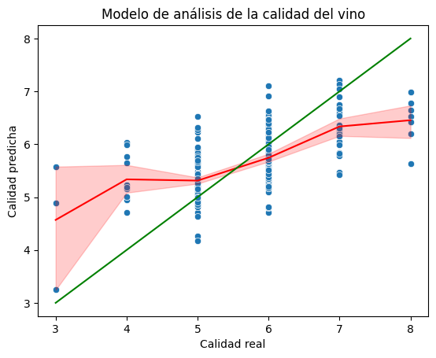

```python
poly = PolynomialFeatures(degree=2)
X_poly_train = poly.fit_transform(X_sc_train)
X_poly_test = poly.fit_transform(X_sc_test)

modelo_poly = LinearRegression()
modelo_poly.fit(X_poly_train, y_sc_train)

y_pred_poly = modelo_poly.predict(X_poly_test)
y_pred_poly_nosc = scaler_y.inverse_transform(y_pred_poly)
y_pred_poly_nosc = y_pred_poly_nosc.reshape(len(y_pred_poly_nosc))

mse_poly = mean_squared_error(y_sc_test, y_pred_poly)
r2_poly = r2_score(y_sc_test, y_pred_poly)
mse_poly, r2_poly

sns.scatterplot(x=y_test, y=y_pred_poly_nosc)
sns.lineplot(x=y_test, y=y_pred_poly_nosc, color='red')
plt.plot([min(y_test), max(y_test)], [min(y_test), max(y_test)], color='green')
plt.xlabel('Calidad real')
plt.ylabel('Calidad predicha')
plt.title('Modelo de análisis de la calidad del vino')
plt.show()
```

La mayor diferencia que encuentro en este modelo respecto a otros anteriores es que en este parece que se consigue predecir con menos error uno de los puntos correspondientes a calidad 3. Por lo demás, es bastante similar.

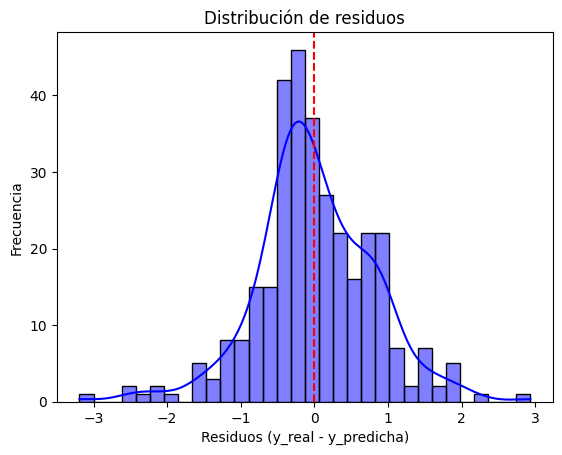

```python
residuos = y_sc_test.reshape(len(y_sc_test)) - y_pred_poly.reshape(len(y_pred_poly))
sns.histplot(residuos, bins=32, kde=True, color="blue")
plt.axvline(x=0, color='red', linestyle='--')
plt.title("Distribución de residuos")
plt.xlabel("Residuos (y_real - y_predicha)")
plt.ylabel("Frecuencia")
plt.show()
```

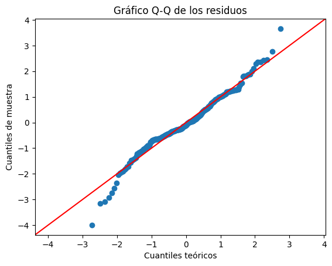

```python
sm.qqplot(residuos, line='45', fit=True)
plt.title('Gráfico Q-Q de los residuos')
plt.xlabel('Cuantiles teóricos')
plt.ylabel('Cuantiles de muestra')
plt.show()
```

El modelo presenta, una vez más, una forma normal aproximada.

## Conclusiones

```python
mse = {mse_nosc : 'regresión lineal sin escalar',
      mse_sc : 'regresión lineal escalada',
      mse_sc_1 : 'regresión lineal tras selección de características mediante VIF',
      mse_pca : 'regresión lineal tras selección de características mediante PCA',
      mse_poly : 'regresión polinómica de grado 2'}

r2 = {r2_nosc : 'regresión lineal sin escalar',
      r2_sc : 'regresión lineal escalada',
      r2_sc_1 : 'regresión lineal tras selección de características mediante VIF',
      r2_pca : 'regresión lineal tras selección de características mediante PCA',
      r2_poly : 'regresión polinómica de grado 2'}

print(f'''====================================================================================================
Rendimiento de los modelos de este cuaderno:
    - Modelo de regresión lineal sin escalar:
        · MSE: {round(mse_nosc, 3)}
        · R²: {round(r2_nosc, 3)}

    - Modelo de regresión lineal escalada:
        · MSE: {round(mse_sc, 3)}
        · R²: {round(r2_sc, 3)}

    - Modelo de regresión lineal tras selección de características mediante VIF:
        · MSE: {round(mse_sc_1, 3)}
        · R²: {round(r2_sc_1, 3)}

    - Modelo de regresión lineal tras selección de características mediante PCA:
        · MSE: {round(mse_pca, 3)}
        · R²: {round(r2_pca, 3)}

    - Modelo de regresión polinómica de grado 2:
        · MSE: {round(mse_poly, 3)}
        · R²: {round(r2_poly, 3)}
====================================================================================================''')
print(f'El modelo con mejor MSE es {mse[min(mse.keys())]} \ny mejor R² es {r2[max(r2.keys())]}')
```

```
====================================================================================================
Rendimiento de los modelos de este cuaderno:
    - Modelo de regresión lineal sin escalar:
        · MSE: 0.4
        · R²: 0.413

    - Modelo de regresión lineal escalada:
        · MSE: 0.4
        · R²: 0.413

    - Modelo de regresión lineal tras selección de características mediante VIF:
        · MSE: 0.395
        · R²: 0.421

    - Modelo de regresión lineal tras selección de características mediante PCA:
        · MSE: 0.393
        · R²: 0.423

    - Modelo de regresión polinómica de grado 2:
        · MSE: 0.64
        · R²: 0.388
====================================================================================================
El modelo con mejor MSE es regresión lineal tras selección de características mediante PCA
y mejor R² es regresión lineal tras selección de características mediante PCA
```

La diferencia es marginal, pero conseguí una pequeña mejoría en el rendimiento del modelo usando seleeción de características mediante PCA.

# Bonus: árbol de regresión

Me quedé un poco intranquilo por la poca precisión del modelo y la dificultad para mejorarlo, así que decidí probar a hacer un modelo de árbol de regresión, por ver si conseguía algo.

Estuve un rato probando con diferentes números de capas y características máximas, y la mejor combinación es la que aquí presento.

```python
from sklearn.tree import DecisionTreeRegressor

X_ar_train, X_ar_test, y_ar_train, y_ar_test = train_test_split(X_1, y, test_size=0.2, random_state=17)
modelo_arbol = DecisionTreeRegressor(criterion='squared_error', random_state=17,
                                     max_depth=6, splitter='random',
                                     max_features=8)
modelo_arbol.fit(X_ar_train, y_ar_train)

y_arbol_pred = modelo_arbol.predict(X_ar_test)
y_arbol_pred = y_arbol_pred.reshape(len(y_arbol_pred))
print("R²:", round(r2_score(y_test, y_arbol_pred), 4))
print("MSE: ", round(mean_squared_error(y_test, y_arbol_pred), 4))
```

```
R²: 0.3654
MSE:  0.4327
```

El MSE no es el peor que hemos tenido, pero el R² sí es el más bajo.

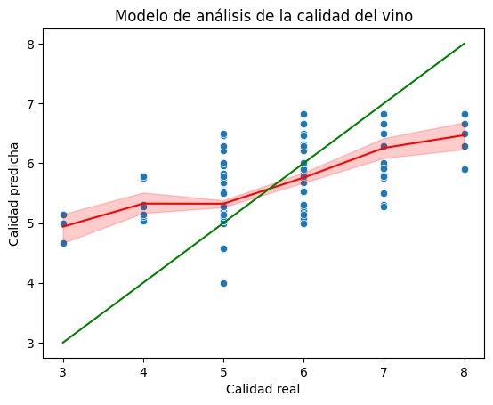

```python
sns.scatterplot(x=y_test, y=y_arbol_pred)
sns.lineplot(x=y_test, y=y_arbol_pred, color='red')
plt.plot([min(y_test), max(y_test)], [min(y_test), max(y_test)], color='green')
plt.xlabel('Calidad real')
plt.ylabel('Calidad predicha')
plt.title('Modelo de análisis de la calidad del vino')
plt.show()
```

Parece que este modelo comete errores muy similares a los anteriores, con muy poca precisión en predicciones de baja calidad y, en general, un MSE alto.

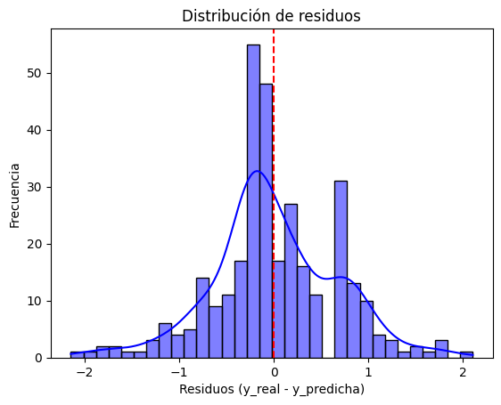

```python
residuos = y_test - y_arbol_pred.reshape(len(y_arbol_pred))
sns.histplot(residuos, bins=32, kde=True, color="blue")
plt.axvline(x=0, color='red', linestyle='--')
plt.title("Distribución de residuos")
plt.xlabel("Residuos (y_real - y_predicha)")
plt.ylabel("Frecuencia")
plt.show()
```

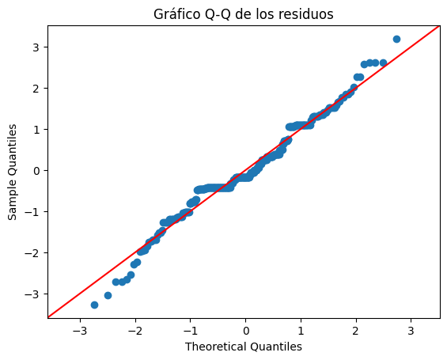

```python
sm.qqplot(residuos, line='45', fit=True)
plt.title('Gráfico Q-Q de los residuos')
plt.show()
```

En cuanto al gráfico Q-Q, es menos uniforme pero se ajusta mejor a lo largo de su longitud, con desviaciones más pequeñas pero más frecuentes.

## Conclusión

Considero que este modelo de árbol de regresión no mejora los modelos anteriores de regresión lineal, especialmente el de selección de características mediante PCA.

Comparativa de rendimiento de los modelos:

[figure not shown]

```python
predicciones = [y_pred, y_pred_nosc, y_pred_nosc_1, y_pca_nosc, y_pred_poly_nosc, y_arbol_pred]
titulos = ['Modelo 1: Modelo lineal no estandarizado',
           'Modelo 2: Modelo lineal estandarizado',
           'Modelo 3: Modelo lineal con selección por VIF',
           'Modelo 4: Modelo lineal con selección por PCA',
           'Modelo 5: Modelo no lineal de grado 2',
           'Modelo 6: Modelo de árbol de regresión']

fig, axes = plt.subplots(3, 2, figsize=(10,15))
axes = axes.flatten()

for i, (y_pred, titulo) in enumerate(zip(predicciones, titulos)):
    ax = axes[i]
    sns.scatterplot(x=y_test, y=y_pred, ax=ax)
    sns.lineplot(x=y_test, y=y_pred, color='red', ax=ax)
    ax.plot([min(y_test), max(y_test)], [min(y_test), max(y_test)], color='green')
    ax.set_xlabel('Calidad real')
    ax.set_ylabel('Calidad predicha')
    ax.set_title(titulo)

plt.show()
```